# Psicometrico cuestionario de actitudes hacia el cuidado

Duban Romero

2022-11-22 17:46:36

# Psicometrico actitudes hacia el cuidado

```r
datos=na.omit(pretest[c("IDencuestado",paste0("A",1:40))])
datos=datos[-1]
```

```r
apply(datos,2,table)
```

```
##    A1  A2  A3  A4  A5  A6  A7  A8  A9 A10 A11 A12 A13 A14 A15 A16 A17 A18 A19
## 1  29  16  36  16  11  13  11  16  18 213  15  13  13  14  23  94  15  14  13
## 2  29   6  79   7  11   5   2  14  10 176  16   9  14  17  23  62  10   6   7
## 3  49  18 195  11  14  14  12  25  10 137  21  14  30  35  29  68   6   9   4
## 4 382 362 294 345 340 335 347 367 298 193 333 345 362 358 348 279 252 297 284
## 5 406 493 291 516 519 528 523 473 559 176 510 514 476 471 472 392 612 569 587
##   A20 A21 A22 A23 A24 A25 A26 A27 A28 A29 A30 A31 A32 A33 A34 A35 A36 A37 A38
## 1  14  11  11  11  20   9  10  59  12 429  20 156  39  20 182   9   9  17  10
## 2  18   2   3   1   5   9   5  75   4 322  11 165  35   9 233   9   5  11   2
## 3  27  13   9   5   9  12  10 144   8  50  11 123 116  10 148  14   7  54  10
## 4 323 238 298 271 296 348 353 340 314  60 297 232 382 361 161 333 240 299 260
## 5 513 631 574 607 565 517 517 277 557  34 556 219 323 495 171 530 634 514 613
##   A39 A40
## 1  10  10
## 2   4   4
## 3  13   6
## 4 267 220
## 5 601 655
```

```r
x<-round(data.frame(apply(datos,2,function(x){cbind(mean(x),sd(x))})),2)
rownames(x)<-c("M","SD")
kable(x)
```

|  | A1 | A2 | A3 | A4 | A5 | A6 | A7 | A8 | A9 | A10 | A11 | A12 | A13 | A14 | A15 | A16 | A17 | A18 | A19 | A20 | A21 | A22 | A23 | A24 | A25 | A26 | A27 | A28 | A29 | … |
| --- | --- | --- | --- | --- | --- | --- | --- | --- | --- | --- | --- | --- | --- | --- | --- | --- | --- | --- | --- | --- | --- | --- | --- | --- | --- | --- | --- | --- | --- | --- |
| M | 4.24 | 4.46 | 3.81 | 4.49 | 4.50 | 4.52 | 4.53 | 4.42 | 4.53 | 2.94 | 4.46 | 4.49 | 4.42 | 4.40 | 4.37 | 3.91 | 4.60 | 4.57 | 4.59 | 4.46 | 4.65 | 4.59 | 4.63 | 4.54 | 4.51 | 4.52 | 3.78 | 4.56 | 1.82 | … |
| SD | 0.94 | 0.74 | 1.11 | 0.73 | 0.71 | 0.70 | 0.66 | 0.78 | 0.76 | 1.47 | 0.78 | 0.72 | 0.76 | 0.79 | 0.87 | 1.32 | 0.72 | 0.70 | 0.69 | 0.79 | 0.65 | 0.66 | 0.63 | 0.76 | 0.68 | 0.66 | 1.16 | 0.67 | 1.06 | … |

```r
corre<-cor(datos)
```

## EFA

```r
KMO(corre)
```

```
## Kaiser-Meyer-Olkin factor adequacy
## Call: KMO(r = corre)
## Overall MSA =  0.98
## MSA for each item =
##   A1   A2   A3   A4   A5   A6   A7   A8   A9  A10  A11  A12  A13  A14  A15  A16
## 0.97 0.98 0.94 0.98 0.98 0.98 0.97 0.98 0.99 0.85 0.97 0.98 0.97 0.98 0.97 0.77
##  A17  A18  A19  A20  A21  A22  A23  A24  A25  A26  A27  A28  A29  A30  A31  A32
## 0.98 0.97 0.98 0.99 0.98 0.98 0.98 0.98 0.98 0.99 0.91 0.99 0.92 0.99 0.73 0.95
##  A33  A34  A35  A36  A37  A38  A39  A40
## 0.98 0.76 0.99 0.98 0.98 0.98 0.98 0.98
```

```r
cortest.bartlett(corre,n=nrow(datos))
```

```
## $chisq
## [1] 29338.35
##
## $p.value
## [1] 0
##
## $df
## [1] 780
```

```r
eigen(corre)$values #5
```

```
##  [1] 19.6432881  2.6403749  1.4641636  1.0954654  1.0756564  0.9373901
##  [7]  0.8744045  0.8359483  0.7342820  0.7044820  0.6656406  0.6462228
## [13]  0.5946745  0.5350032  0.5200269  0.4995218  0.4730031  0.4558674
## [19]  0.4466948  0.4235862  0.4066280  0.3859944  0.3699497  0.3275946
## [25]  0.3057184  0.2962750  0.2788559  0.2569590  0.2532208  0.2298411
## [31]  0.2138041  0.2108905  0.1950972  0.1818281  0.1674019  0.1548918
## [37]  0.1360463  0.1262463  0.1249142  0.1121462
```

```r
fa.parallel(datos,fm="pa",cor="cor",plot = F) # 7
```

```
## Parallel analysis suggests that the number of factors =  7  and the number of components =  3
```

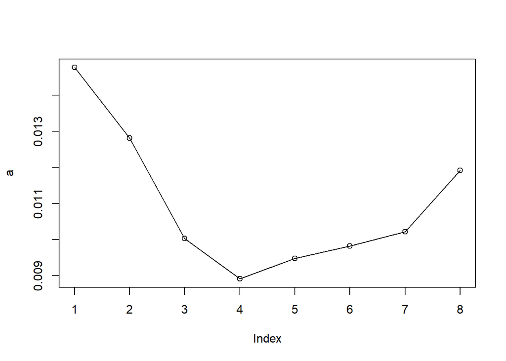

```
## integer(0)
```

```r
a<-VSS(datos,fm="pa",cor="cor",plot=F)$map; plot(a)+lines(a) #4
```

```r
(a<-fa(datos,nfactors =4 ,fm="pa",rotate="promax",cor="cor")$loadings)
```

```
##
## Loadings:
##     PA1    PA4    PA3    PA2
## A1                 0.665
## A2                 0.818
## A3                 0.488
## A4          0.121  0.681  0.103
## A5   0.101  0.135  0.666
## A6          0.157  0.696  0.101
## A7   0.232  0.132  0.592
## A8   0.219         0.514
## A9   0.175  0.249  0.390  0.116
## A10                       0.464
## A11  0.592         0.252
## A12  0.635         0.195 -0.136
## A13  0.660 -0.186  0.270 -0.147
## A14  0.423         0.246 -0.115
## A15  0.543         0.235
## A16         0.166         0.489
## A17  0.614  0.180         0.169
## A18  0.879
## A19  0.755         0.133
## A20  0.677         0.103
## A21  0.626  0.318
## A22  0.646  0.198
## A23  0.727  0.249
## A24  0.722  0.218 -0.148
## A25  0.592  0.346
## A26  0.348  0.432  0.118
## A27         0.136        -0.435
## A28  0.249  0.591
## A29        -0.223 -0.101  0.352
## A30  0.311  0.382
## A31                       0.693
## A32         0.135  0.171 -0.288
## A33  0.219  0.381  0.127
## A34                       0.689
## A35  0.106  0.578  0.141
## A36  0.135  0.900
## A37         0.519  0.150 -0.211
## A38  0.279  0.736
## A39         0.921
## A40         0.925
##
##                  PA1   PA4   PA3   PA2
## SS loadings    6.670 5.220 4.026 2.058
## Proportion Var 0.167 0.131 0.101 0.051
## Cumulative Var 0.167 0.297 0.398 0.449
```

```r
(b<-fa(datos,nfactors =5 ,fm="pa",rotate="promax",cor="cor")$loadings)
```

```
##
## Loadings:
##     PA1    PA4    PA3    PA5    PA2
## A1                 0.663
## A2                 0.847
## A3                 0.496
## A4   0.117         0.691
## A5   0.100  0.118  0.639
## A6          0.147  0.654
## A7   0.238         0.591
## A8   0.149         0.479  0.142
## A9   0.238  0.191  0.396
## A10                              0.453
## A11  0.264         0.115  0.539
## A12  0.310                0.562
## A13  0.202 -0.165         0.753
## A14  0.107                0.538
## A15  0.185                0.587  0.188
## A16 -0.155  0.196         0.161  0.590
## A17  0.712         0.105
## A18  0.823                0.176
## A19  0.706 -0.104  0.185  0.149
## A20  0.490                0.324
## A21  0.725  0.160
## A22  0.684         0.131
## A23  0.844
## A24  0.671  0.104 -0.125  0.188
## A25  0.536  0.263 -0.117  0.219
## A26  0.464  0.327  0.157
## A27         0.155               -0.389
## A28  0.420  0.483
## A29        -0.269        -0.143  0.268
## A30  0.389  0.293
## A31                       0.163  0.774
## A32         0.184         0.200 -0.205
## A33  0.166  0.367         0.196
## A34  0.124                       0.639
## A35  0.184  0.542
## A36  0.418  0.773        -0.168
## A37         0.563         0.140
## A38  0.517  0.597        -0.135
## A39  0.215  0.852        -0.118
## A40  0.326  0.806        -0.240
##
##                  PA1   PA4   PA3   PA5   PA2
## SS loadings    6.040 3.971 3.679 2.397 1.962
## Proportion Var 0.151 0.099 0.092 0.060 0.049
## Cumulative Var 0.151 0.250 0.342 0.402 0.451
```

```r
(c<-fa(datos,nfactors =7 ,fm="pa",rotate="promax",cor="cor")$loadings)
```

```
##
## Loadings:
##     PA1    PA4    PA3    PA5    PA2    PA7    PA6
## A1         -0.152  0.591                0.221  0.150
## A2   0.118         0.728                0.138  0.200
## A3                 0.391                       0.462
## A4   0.192         0.634
## A5   0.150         0.570  0.104
## A6          0.215  0.559  0.238        -0.135
## A7   0.194  0.184  0.479  0.223        -0.203  0.120
## A8          0.138  0.355  0.250        -0.140  0.245
## A9   0.245  0.211  0.332
## A10                              0.443
## A11  0.233                0.634
## A12  0.263                0.677
## A13  0.235 -0.179         0.665         0.180
## A14                       0.500
## A15  0.237 -0.182         0.381  0.226  0.351
## A16 -0.130  0.132                0.606  0.144
## A17  0.802         0.118                      -0.120
## A18  0.853                0.150
## A19  0.760 -0.117  0.152  0.114
## A20  0.519                0.277
## A21  0.827                                    -0.165
## A22  0.765         0.128
## A23  0.890
## A24  0.676  0.110 -0.137  0.167
## A25  0.524  0.259 -0.171  0.150                0.179
## A26  0.494  0.287  0.118
## A27         0.137               -0.370
## A28  0.413  0.465                              0.165
## A29        -0.163                0.227 -0.313  0.191
## A30  0.436  0.216                       0.149
## A31                       0.124  0.731
## A32                             -0.150  0.441
## A33  0.119  0.346                0.111  0.177  0.305
## A34  0.114                       0.602 -0.160
## A35  0.175  0.510
## A36  0.429  0.719        -0.126
## A37 -0.109  0.554         0.174 -0.109
## A38  0.550  0.547                             -0.121
## A39  0.190  0.825
## A40  0.317  0.782        -0.144
##
##                  PA1   PA4   PA3   PA5   PA2   PA7   PA6
## SS loadings    6.760 3.597 2.718 2.215 1.827 0.774 0.697
## Proportion Var 0.169 0.090 0.068 0.055 0.046 0.019 0.017
## Cumulative Var 0.169 0.259 0.327 0.382 0.428 0.447 0.465
```

El modelo de cuatro factores combinó los items de las dimensiones teoricas de cuidado fisico y el cuidado etico. El modelo de 7 factores incluye tres dimensiones con pocos items y que son combinaciones de items de las diferentes dimensiones. Por lo tanto, ambos modelos se alejan significativamente de la estructura teorica. Por su parte, el modelo de cinco factores hace una discriminación de los factores más proxima a la estructura teorica. En ese sentido, se toma este factor como punto de partida y se retirarán los items que sean necesarios teniendo en cuenta que tengan saturaciones >.30 y que estén bien diferenciados entre los factores.

```r
(a<-fa(datos[-c(10,16,27,31,34)],nfactors =4 ,fm="pa",rotate="promax",cor="cor")$loadings)
```

```
##
## Loadings:
##     PA1    PA4    PA2    PA3
## A1  -0.112         0.628
## A2                 0.834
## A3                 0.483
## A4   0.159         0.719
## A5   0.156         0.672
## A6   0.169         0.702
## A7   0.217  0.141  0.612
## A8          0.178  0.477
## A9   0.325         0.428
## A11         0.582  0.138  0.123
## A12         0.615         0.219
## A13 -0.215  0.736         0.297
## A14         0.459         0.311
## A15         0.556  0.124
## A17  0.495  0.392  0.112 -0.276
## A18  0.378  0.648        -0.139
## A19  0.319  0.555  0.177 -0.161
## A20  0.121  0.566
## A21  0.579  0.392        -0.119
## A22  0.434  0.436  0.108
## A23  0.567  0.465        -0.162
## A24  0.431  0.522 -0.145
## A25  0.449  0.433 -0.140  0.181
## A26  0.543  0.174  0.153
## A28  0.665         0.112
## A29                      -0.403
## A30  0.490  0.166
## A32         0.101         0.410
## A33  0.351  0.156         0.199
## A35  0.493                0.321
## A36  0.903                0.184
## A37  0.305                0.494
## A38  0.823
## A39  0.808 -0.164         0.345
## A40  0.900 -0.187         0.166
##
##                  PA1   PA4   PA2   PA3
## SS loadings    6.436 4.236 3.787 1.391
## Proportion Var 0.184 0.121 0.108 0.040
## Cumulative Var 0.184 0.305 0.413 0.453
```

```r
write.csv2(a,"EFAprac_4_2.csv")
```

La estructura factorial se distancia bastante de la estructura teorica. A continuación usaremos CFA para evaluar los indices de ajuste del modelo teorico.

## CFA

Examinamos la normalidad multivariante

```r
MVN::mvn(datos,mvnTest = "mardia")$multivariateNormality
```

```
##              Test        Statistic p value Result
## 1 Mardia Skewness 111279.847496536       0     NO
## 2 Mardia Kurtosis 413.503262403309       0     NO
## 3             MVN             <NA>    <NA>     NO
```

Diseñamos diferentes variantes del modelo

```r
modelo1<-'
cognitivo =~ A1+A2+A3+A4+A5+A6+A7+A8
fisico =~ A9+A10+A11+A12+A13+A14+A15+A16+A17+A18+A19+A20+A21+A22
etico =~ A23+A24+A25+A26+A27+A28+A29
emocional =~ A30+A31+A32+A33+A34+A35
trascend =~ A36+A37+A38+A39+A40
'

modelo2<-'
cognitivo =~ A1+A2+A3+A4+A5+A6+A7+A8
alimentac =~ A9+A10+A11+A12
suenio =~ A13+A14+A15+A16
salud =~ A17+A18+A19+A20+A21+A22
etico =~ A23+A24+A25+A26+A27+A28+A29
emocional =~ A30+A31+A32+A33+A34+A35
trascend =~ A36+A37+A38+A39+A40
'
```

Evaluamos los modelos

```r
a1<-cfa(modelo1,datos,estimator="MLR")
a2<-cfa(modelo2,datos,estimator="MLR")
```

Examinamos los indices de ajuste

```r
x1<-round(fitMeasures(a1)[c("chisq.scaled","df.scaled","cfi.robust","tli.robust","rmsea.robust")],3)
x2<-round(fitMeasures(a2)[c("chisq.scaled","df.scaled","cfi.robust","tli.robust","rmsea.robust")],3)
```

```r
summary(a2)
```

```
## lavaan 0.6-12 ended normally after 184 iterations
##
##   Estimator                                         ML
##   Optimization method                           NLMINB
##   Number of model parameters                       101
##
##   Number of observations                           895
##
## Model Test User Model:
##                                               Standard      Robust
##   Test Statistic                              3843.877    2415.089
##   Degrees of freedom                               719         719
##   P-value (Chi-square)                           0.000       0.000
##   Scaling correction factor                                  1.592
##     Yuan-Bentler correction (Mplus variant)
##
## Parameter Estimates:
##
##   Standard errors                             Sandwich
##   Information bread                           Observed
##   Observed information based on                Hessian
##
## Latent Variables:
##                    Estimate  Std.Err  z-value  P(>|z|)
##   cognitivo =~
##     A1                1.000
##     A2                1.077    0.042   25.563    0.000
##     A3                0.846    0.053   15.910    0.000
##     A4                1.096    0.046   23.688    0.000
##     A5                1.100    0.044   25.107    0.000
##     A6                1.139    0.052   22.099    0.000
##     A7                1.095    0.051   21.543    0.000
##     A8                1.073    0.051   20.840    0.000
##   alimentac =~
##     A9                1.000
##     A10              -0.291    0.086   -3.389    0.001
##     A11               1.091    0.077   14.218    0.000
##     A12               1.086    0.078   13.998    0.000
##   suenio =~
##     A13               1.000
```

[output cut: 96 more lines]

```
##    .A33               0.306    0.054    5.677    0.000
##    .A34               2.004    0.056   35.572    0.000
##    .A35               0.161    0.024    6.812    0.000
##    .A36               0.047    0.007    6.530    0.000
##    .A37               0.421    0.052    8.163    0.000
##    .A38               0.077    0.015    5.294    0.000
##    .A39               0.096    0.022    4.379    0.000
##    .A40               0.064    0.018    3.565    0.000
##     cognitivo         0.298    0.045    6.697    0.000
##     alimentac         0.309    0.050    6.160    0.000
##     suenio            0.388    0.047    8.288    0.000
##     salud             0.318    0.047    6.746    0.000
##     etico             0.326    0.047    6.942    0.000
##     emocional         0.282    0.045    6.295    0.000
##     trascend          0.348    0.047    7.375    0.000
```

Al examinar el modelo 2 notamos que los items A31 Y 34 no ajustan bien en su factor. Por ello probaremos el modelo, pero si esos dos items.

```r
modelo3<-'cognitivo =~ A1+A2+A3+A4+A5+A6+A7+A8
alimentac =~ A9+A10+A11+A12
suenio =~ A13+A14+A15+A16
salud =~ A17+A18+A19+A20+A21+A22
etico =~ A23+A24+A25+A26+A27+A28+A29
emocional =~ A30+A32+A33+A35
trascend =~ A36+A37+A38+A39+A40'
```

```r
a3<-cfa(modelo3,datos,estimator="MLR")
x3<-round(fitMeasures(a3)[c("chisq.scaled","df.scaled","cfi.robust","tli.robust","rmsea.robust")],3)
```

Se puede observar que los items A10 y A29 tienen un aporte inverso al factor aún cuando estos ya se habían invertido. Esto indica problemas en la validez de contenido de estos items. Cuando se examinan las correlaciones parciales, el item A16 muestra bajas correlacciones con los items de su factor, lo cual provoca problemas en la estimación de la confiabuildiad. Por ello procedemos a probar un nuevo modelo eliminando estos items.

```r
modelo4<-'cognitivo =~ A1+A2+A3+A4+A5+A6+A7+A8
alimentac =~ A9+A11+A12
suenio =~ A13+A14+A15
salud =~ A17+A18+A19+A20+A21+A22
etico =~ A23+A24+A25+A26+A27+A28
emocional =~ A30+A32+A33+A35
trascend =~ A36+A37+A38+A39+A40'
```

```r
a4<-cfa(modelo4,datos,estimator="MLR")
x4<-round(fitMeasures(a4)[c("chisq.scaled","df.scaled","cfi.robust","tli.robust","rmsea.robust")],3)
```

Los modelos que obtuvimos derivan del modelo 2. Ahora evaluaremos nuevamos modelos derivados del modelo 1.

```r
modelo5<-'
cognitivo =~ A1+A2+A3+A4+A5+A6+A7+A8
fisico =~ A9+A11+A12+A13+A14+A15+A16+A17+A18+A19+A20+A21+A22
etico =~ A23+A24+A25+A26+A27+A28
emocional =~ A30+A32+A33+A35
trascend =~ A36+A37+A38+A39+A40
'
```

```r
a5<-cfa(modelo5,datos,estimator="MLR")
x5<-round(fitMeasures(a5)[c("chisq.scaled","df.scaled","cfi.robust","tli.robust","rmsea.robust")],3)
```

```r
rbind(x1,x2,x3,x4,x5)
```

```
##    chisq.scaled df.scaled cfi.robust tli.robust rmsea.robust
## x1     2613.461       730      0.892      0.885        0.068
## x2     2415.089       719      0.905      0.897        0.065
## x3     1847.053       644      0.928      0.921        0.059
## x4     1433.447       539      0.942      0.936        0.057
## x5     1764.668       584      0.924      0.918        0.063
```

La estructura factorial del modelo con mejor ajuste es la siguiente:

```r
summary(a4)
```

```
## lavaan 0.6-12 ended normally after 157 iterations
##
##   Estimator                                         ML
##   Optimization method                           NLMINB
##   Number of model parameters                        91
##
##   Number of observations                           895
##
## Model Test User Model:
##                                               Standard      Robust
##   Test Statistic                              2540.125    1433.447
##   Degrees of freedom                               539         539
##   P-value (Chi-square)                           0.000       0.000
##   Scaling correction factor                                  1.772
##     Yuan-Bentler correction (Mplus variant)
##
## Parameter Estimates:
##
##   Standard errors                             Sandwich
##   Information bread                           Observed
##   Observed information based on                Hessian
##
## Latent Variables:
##                    Estimate  Std.Err  z-value  P(>|z|)
##   cognitivo =~
##     A1                1.000
##     A2                1.077    0.042   25.554    0.000
##     A3                0.846    0.053   15.912    0.000
##     A4                1.096    0.046   23.680    0.000
##     A5                1.100    0.044   25.097    0.000
##     A6                1.139    0.052   22.085    0.000
##     A7                1.095    0.051   21.540    0.000
##     A8                1.073    0.051   20.844    0.000
##   alimentac =~
##     A9                1.000
##     A11               1.091    0.077   14.216    0.000
##     A12               1.086    0.078   13.983    0.000
##   suenio =~
##     A13               1.000
##     A14               0.917    0.039   23.645    0.000
```

[output cut: 86 more lines]

```
##    .A32               0.887    0.064   13.884    0.000
##    .A33               0.305    0.054    5.668    0.000
##    .A35               0.160    0.023    6.812    0.000
##    .A36               0.047    0.007    6.524    0.000
##    .A37               0.421    0.052    8.169    0.000
##    .A38               0.077    0.015    5.285    0.000
##    .A39               0.096    0.022    4.380    0.000
##    .A40               0.064    0.018    3.565    0.000
##     cognitivo         0.298    0.045    6.698    0.000
##     alimentac         0.309    0.050    6.153    0.000
##     suenio            0.389    0.047    8.314    0.000
##     salud             0.318    0.047    6.749    0.000
##     etico             0.327    0.047    6.950    0.000
##     emocional         0.282    0.045    6.278    0.000
##     trascend          0.348    0.047    7.372    0.000
```

## Confiabilidad

```r
set.seed(123)
(a1<-as.numeric(psych::alpha(datos[1:8])$total[1])); my_alphaCI(datos[1:8])
```

```
## [1] 0.8958863
```

```
## [1] 0.8505988 0.9247200
```

```r
(a2<-as.numeric(psych::alpha(datos[c(9,11,12)])$total[1])); my_alphaCI(datos[c(9,11,12)])
```

```
## [1] 0.8213118
```

```
## [1] 0.7352058 0.8799770
```

```r
(a3<-as.numeric(psych::alpha(datos[13:15])$total[1])); my_alphaCI(datos[13:15])
```

```
## [1] 0.7896882
```

```
## [1] 0.7021056 0.8506319
```

```r
(a4<-as.numeric(psych::alpha(datos[17:22])$total[1]));my_alphaCI(datos[17:22])
```

```
## [1] 0.9320365
```

```
## [1] 0.8972021 0.9550237
```

```r
(a4.1<-as.numeric(psych::alpha(datos[23:28])$total[1]));my_alphaCI(datos[23:28])
```

```
## [1] 0.8205065
```

```
## [1] 0.7437569 0.8688672
```

```r
(a5<-as.numeric(psych::alpha(datos[c(30,32,33,35)])$total[1])); my_alphaCI(datos[c(30,32,33,35)])
```

```
## [1] 0.7106379
```

```
## [1] 0.5996741 0.7865820
```

```r
(a6<-as.numeric(psych::alpha(datos[36:40])$total[1])); my_alphaCI(datos[36:40])
```

```
## [1] 0.917381
```

```
## [1] 0.8682776 0.9457559
```